# “Adherència” basat en registres clínics: Estudi Met+

25 de febrer del 2020

## Guió

- Met+
- “Adherència” i MPR
- Dades
- Exemples: Mapeig gràfic de dades
- Preprocessament de dades
- IdMaps
- Anàlisi

## Estudi Met+

- 3 grups Antidiabetics orals (ADO): Sulfonilurea, IDPP-4, iSGLT2
- Pacients DM2 tractats amb metformina i insuficient control glucémic
- Objectius:
  - Principal: Evaluar canvis en HbA1c i pes (Fins 24 mesos)
  - Secundari 1: ….
  - ….
  - ….
  - ….
  - Secundari 5: Adherència de cada grup de tratament
  - ….

## Taxa de possessió de medicament

### MPR

- The therapeutic adherence will be assessed through pharmacy invoice data (drug dispensing)
- For each patient will be calculated The medication possession ratio (MPR)

\(MPR = \frac{TempsDispensació(D)} {TempsTranscorregut(P)}\)

On:

- D: Temps de dispensat (“real”) del fàrmac d’estudi
- P: Temps prescrit (“teoric”) durant període de seguiment o fins la prematura finalització

## Adherència

\(MPR = \frac{f(D) } { f(P)} \in [0-1]\),

on f(D) és la covertura de la **dispensació**, i f(P) = Període de **prescripció**

| Adherènca | Criteri |
| --- | --- |
| Good | \(MPR \ge 0.8\) |
| Low | \(MPR < 0.8\) |

- Si D=0 –> MPR=0
- Dispensació va vinculada a prescripció, Per tant:

  \(D \le P\)  
  \(D \in P\)  
  Si \(D(observada) \ge P(observada)\): MPR=1

## Dades disponibles

### Tractament dispensat i prescrit segons dades SIDIAP

Històric de fàrmacs prescrits d’un pacient

| idp | cod | agr | dat | dbaixa |
| --- | --- | --- | --- | --- |
| acba786c | A10BK03 | iSGLT2 | 20170307 | 20171228 |
| acba786c | A10BK03 | iSGLT2 | 20171229 | 20180627 |

Històric de fàrmacs dispensats d’un pacient

| idp | cod | dat | agr | env |
| --- | --- | --- | --- | --- |
| acba786c | A10BK03 | 201703 | iSGLT2 | 1 |
| acba786c | A10BK03 | 201704 | iSGLT2 | 1 |
| acba786c | A10BK03 | 201705 | iSGLT2 | 1 |
| acba786c | A10BK03 | 201706 | iSGLT2 | 1 |
| acba786c | A10BK03 | 201707 | iSGLT2 | 1 |

## Exemples

### Escenari 1

\(Dispensació \in Prescripció\)

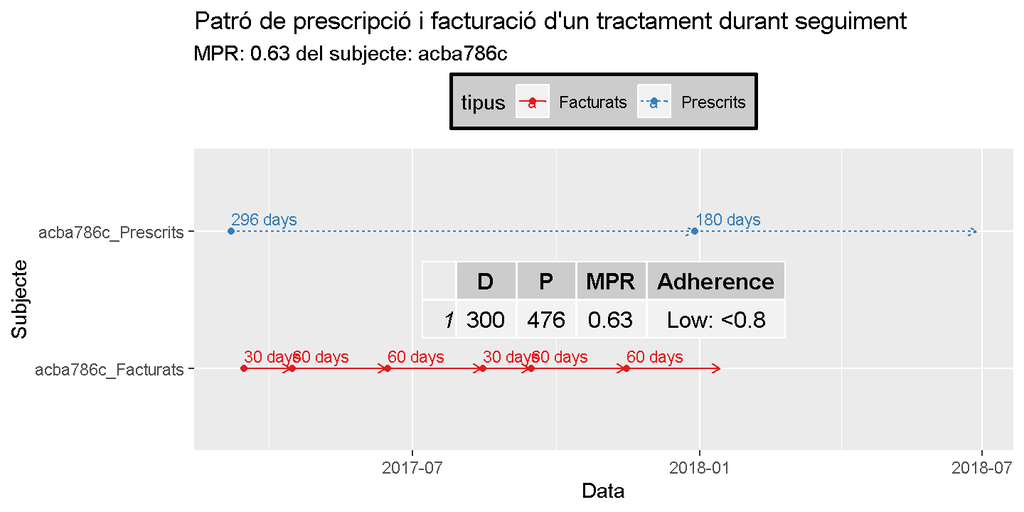

## Exemples

### Escenari 2

No consta dispensació

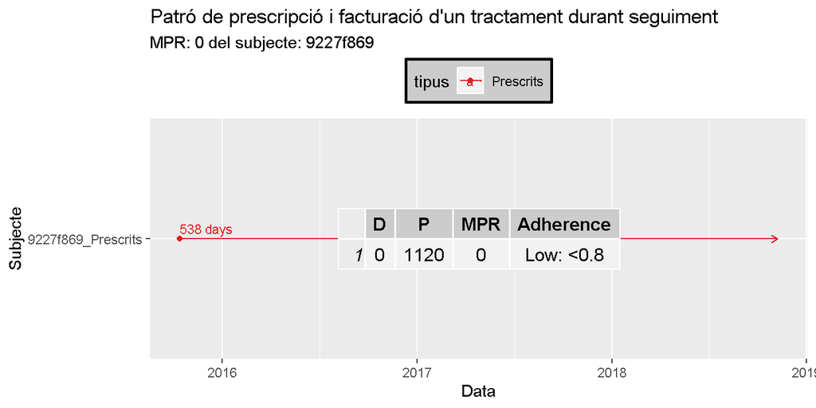

## Exemples

### Escenari 3

Dispensació = Prescripció

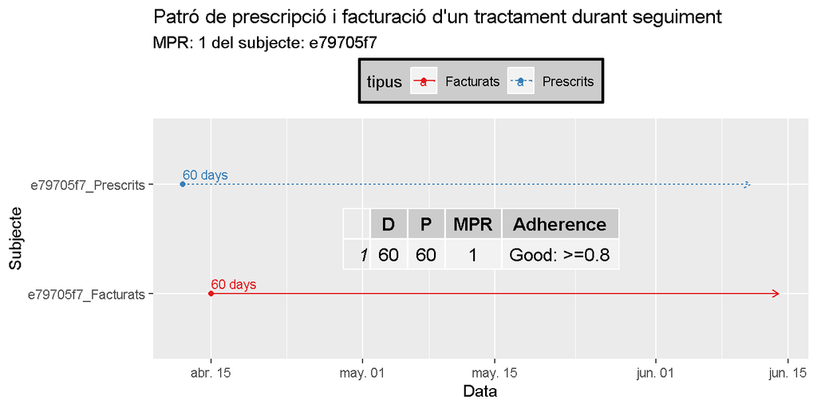

## Exemples

### Escenari 4

Dispensació > Prescripció

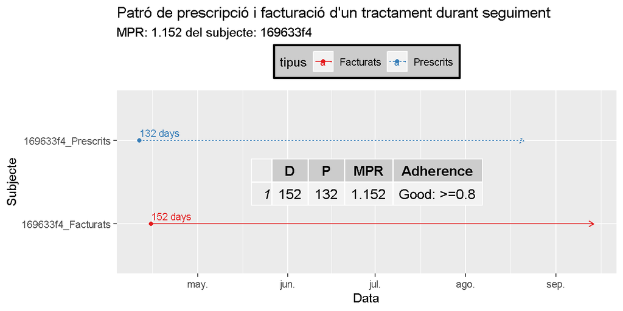

## Exemples

### Escenari 5

Inici de dispensació previa a la prescripció

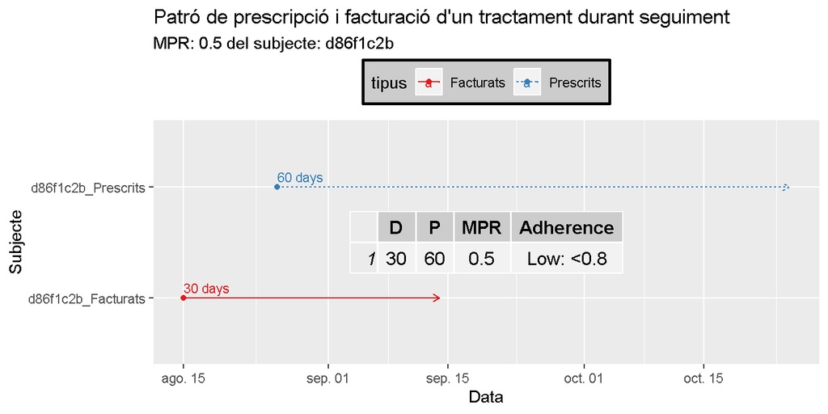

## Procesament de dades

### Període de prescripció i temps de dispensanció

1. Actualitzar Prescripció amb dispensació
2. Estimar data fi de dispensació
3. Eliminar solapaments i discontinuïtats (gaps)
4. Delimitar finestra de seguiment

## Procesament de dades

### 1. Actualitzar prescripció

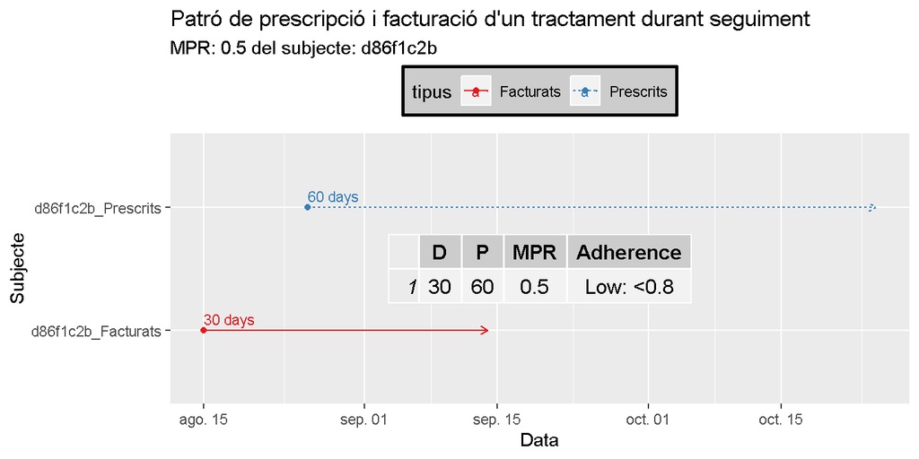

## Procesament de dades

### 1. Actualitzar prescripció

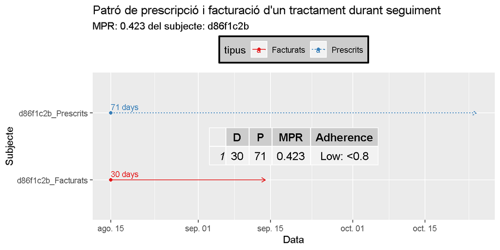

## Procesament de dades

### 2. Estimació de dispensació

Dades de facturació crues

| idp | cod | dat | agr | env |
| --- | --- | --- | --- | --- |
| 948d638a | A10BB09 | 201510 | SU | 1 |
| 948d638a | A10BB09 | 201512 | SU | 1 |
| 948d638a | A10BB09 | 201601 | SU | 1 |

Dades de facturació precuinades

| idp | cod | dat | agr | env | dbaixa |
| --- | --- | --- | --- | --- | --- |
| 948d638a | A10BB09 | 20151015 | SU | 1 | 20151114 |
| 948d638a | A10BB09 | 20151215 | SU | 1 | 20160114 |
| 948d638a | A10BB09 | 20160115 | SU | 1 | 20160214 |

## Procesament de dades

### 2. Estimació de dispensació

- Data inici: Asumim 15 de cada mes
- Data fi: Depén de la posologia i la dosi (Depén de cada fàrmac)
  - Assumpció general: 1 envás ADO = 30 dies
  - Ajust per factor de conversió segons dosi i per tant cobertura

## Procesament de dades

### 2. Estimació de dispensació

Històric de facturacions (n=4) de Sulfunilurea assumint **30 dies** de cobertura per envàs

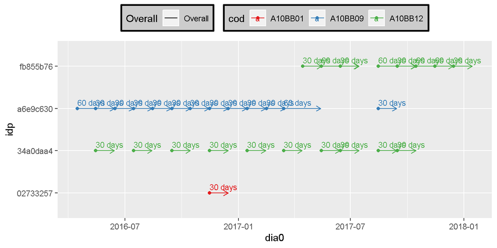

## Procesament de dades

### 2. Estimació de dispensació

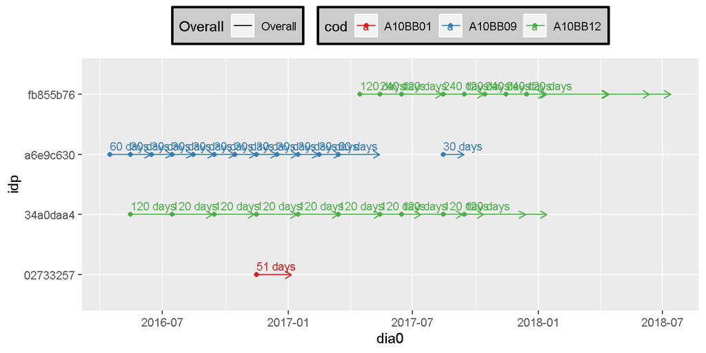

## Procesament de dades

### 3. Eliminar solapaments i discontinuïtats

Dades processades post **eliminació de discontinuïtats i solapaments**

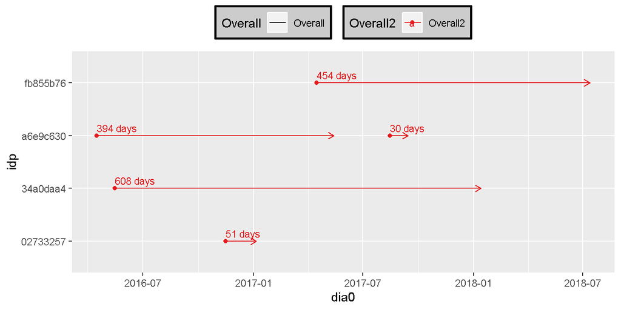

## Procesament de dades

### 4. Delimitar finestra de seguiment

Seguiment fins 24 mesos, 31/12/2017 o prematura finalització (defunció /trasllat)

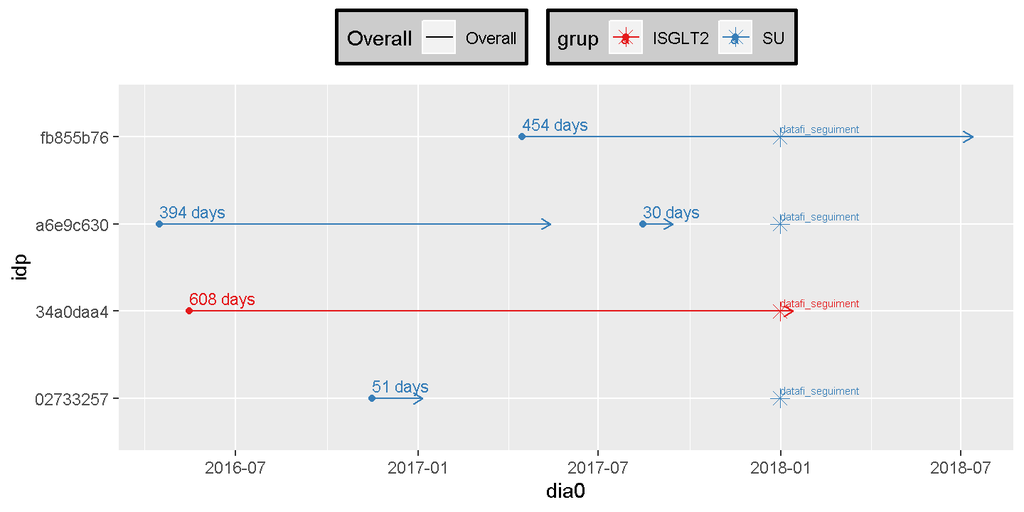

## Procesament de dades

### 4. Delimitar finestra de seguiment

Seguiment fins 24 mesos, 31/12/2017 o prematura finalització (defunció/trasllat)

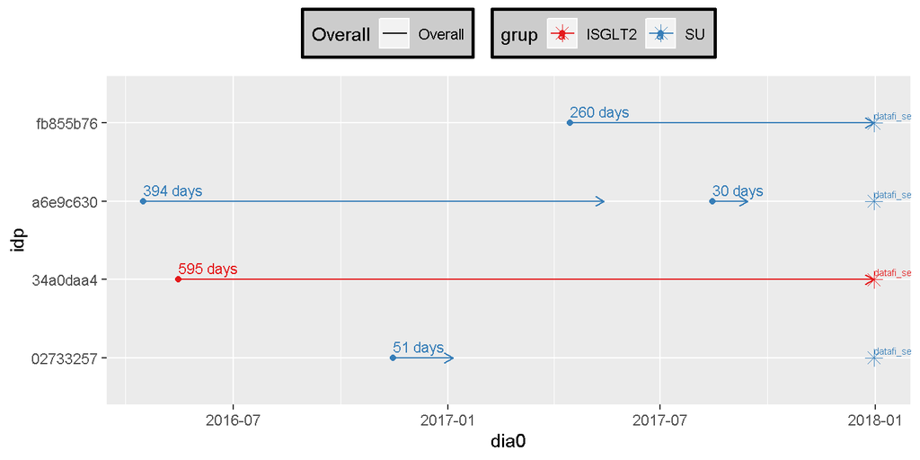

## Resum

### Mapeig de dispensacions

Dades originals de dispensacions: Mostreig de 5 pacients per ATC

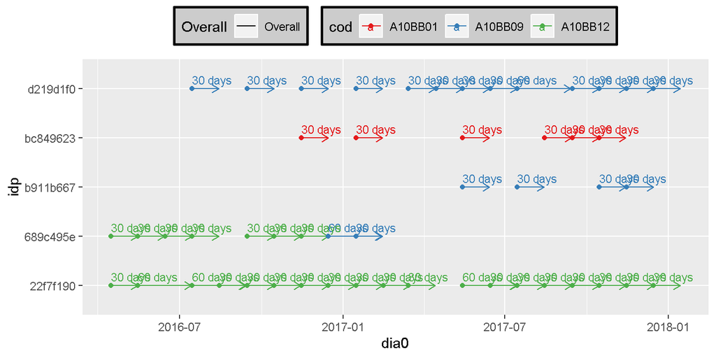

## Resum

### Mapeig de dispensacions

Dades processades: Post estimació de fi de coberura, eliminació de gaps i solapaments

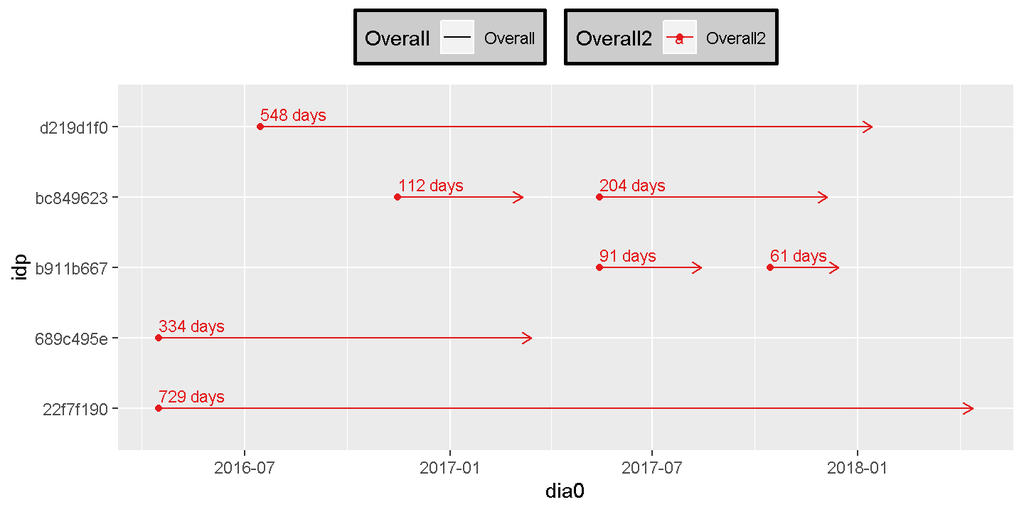

## Resum

### Mapeig de prescripcions

Dades originals de prescripcions

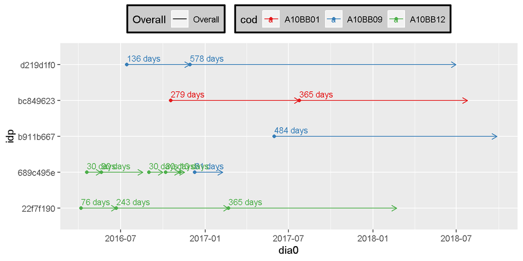

## Resum

### Mapeig de prescripcions

Dades processades: **Actualització amb dispensació**

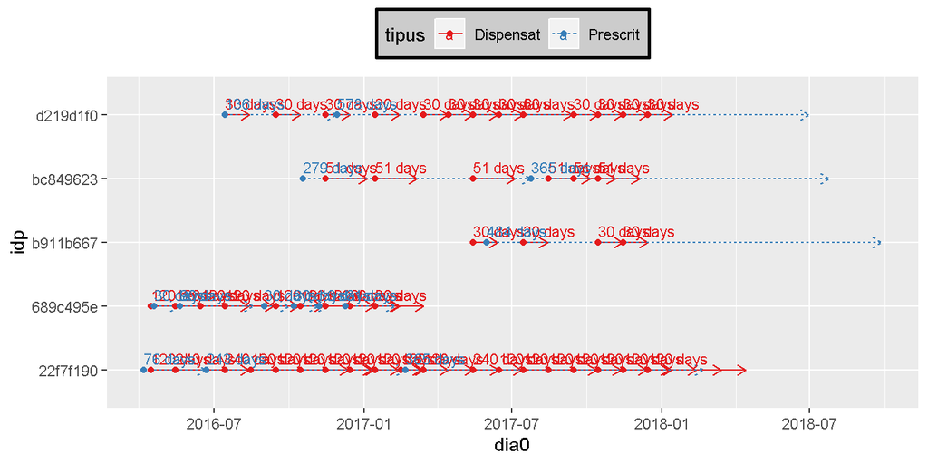

## Resum

### Mapeig de prescripcions

Dades processades: Actualització amb dispensació + **eliminats solapaments i gaps**

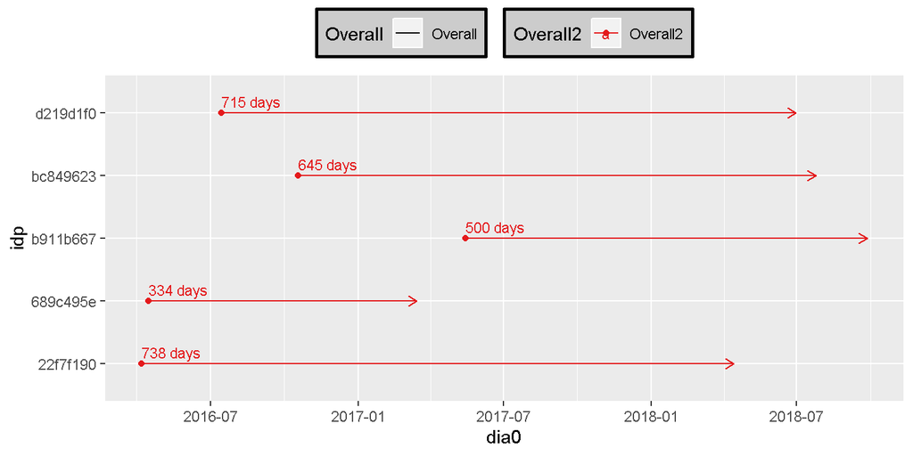

## Resum

### Mapeig de prescripcions

Dades processades: Actualització amb dispensació + eliminats de solapaments i gaps + **truncament final de seguiment**

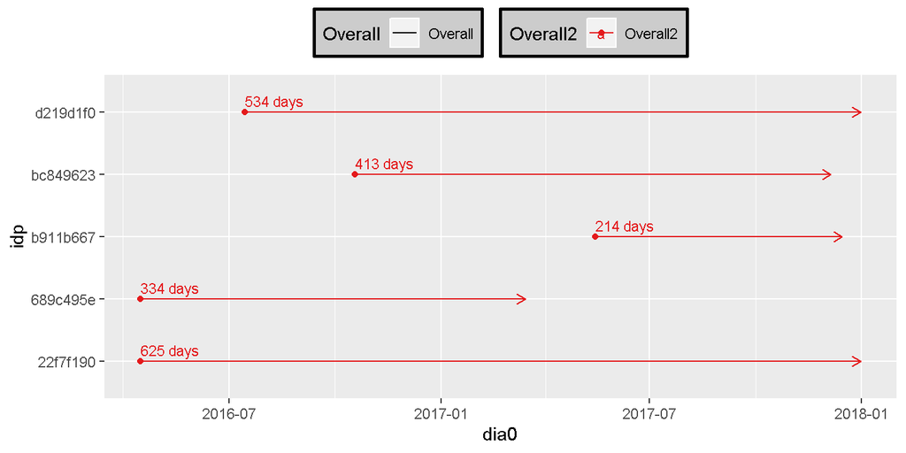

## Mapejar registres clínics

### Aplicació Shiny

> [IdMaps](https://www.shinyapps.io/admin/#/dashboard): Eina per visualitzar dades longitudinals

> Utilitats:
- Validar i controlar processos
- Visualitzar històrics (longitudinals)
- Planificar indicadors
- Detecció d’errades (Descartar objectius)

Paràmetres (SU, n=1-4, llavor=201)

## Anàlisi de dades

- Anàlisi sota tractament (On treatment)
- Finalització de tractament dispensat (+3 mesos)
- Conseqüències:
  - Reducció de temps de seguiment
  - Increment de missings
  - Increment del % de censura

## Gràcies Moltes

**Jordi Real & Ramón Puig**

USR-Barcelona, DAP-CAT  
IDIAP Jordi Gol 25 de Febrer del 2020